# Module 3 Project, Part C: Check Your Numbers

This is the output of one complete run of the project, with a fixed random seed. Use it to see whether your own results are in the right ballpark: the same order of magnitude, the same conclusions, the same first digit or two. It is not an answer key. There is no code and no explanation here, and the exam asks about *your* project, not this one.

What should match, and how closely:

- **Exact values** do not depend on random numbers and should match to every digit shown: the 2012 coefficient and its SE from `summary`, the autocorrelations, the SE of the `casual ~ temp` slope from `summary`, and the two mean absolute residuals in C.2(a), and the two medians and their difference in C.2(b).
- **Bootstrap estimates** vary from run to run. Your bootstrap SEs and interval endpoints should agree with these to about two significant digits.

# Part C: Resampling structured data

## C.1(a)

The 2012 coefficient and its SE from `summary`, the lag-1 autocorrelation of the residuals, and the autocorrelations to lag 14.

```
##   Estimate Std. Error
##  0.8470931  0.2465062
```

```
## [1] 0.6585877
```

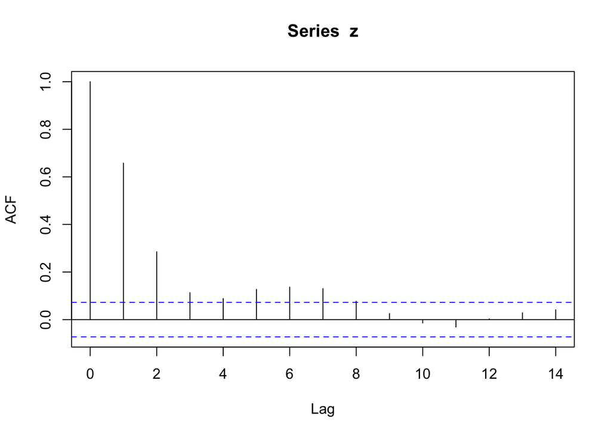

## C.1(b)

The block bootstrap SE of the 2012 effect against $\ell$, plotted and printed, then the 95% normal intervals with $\ell = 14$ and with the SE from `summary`.

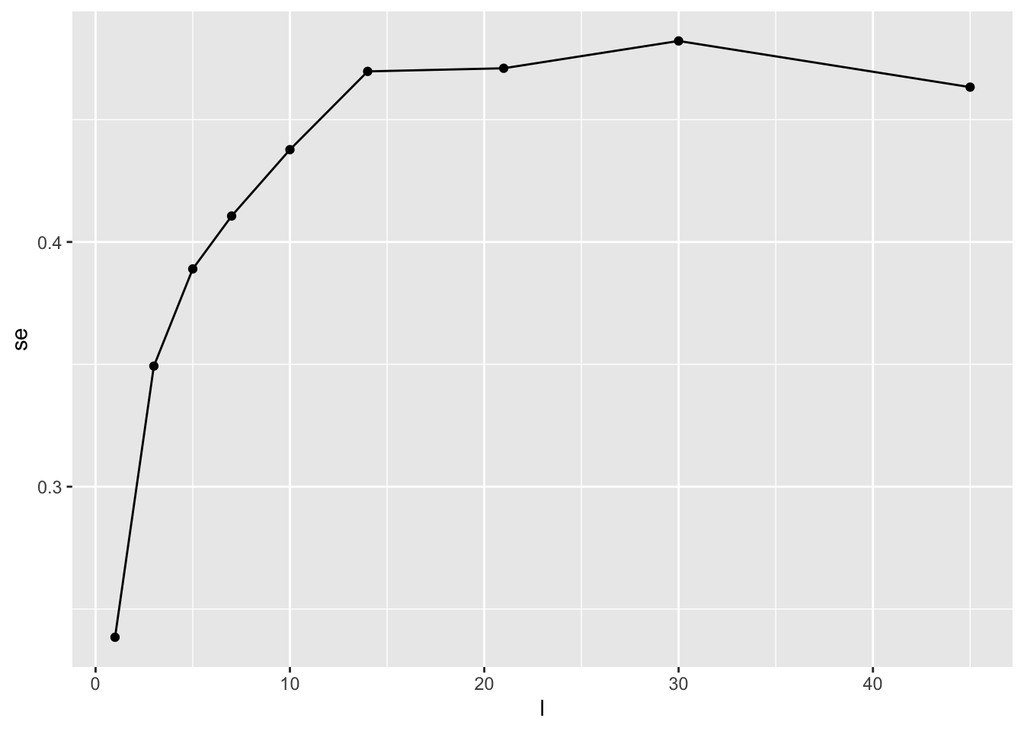

```
##     1     3     5     7    10    14    21    30    45
## 0.238 0.349 0.389 0.411 0.438 0.470 0.471 0.482 0.463
```

```
##                 [,1]     [,2]
## block_14 -0.07355014 1.767736
## summary   0.36394102 1.330245
```

## C.2(a)

The SEs from resampling cases, resampling errors, the wild bootstrap and `summary`, then the mean absolute residual for the 10 days farthest from the mean temperature and for all days.

```
##    cases   errors     wild       lm
## 2.116698 2.535891 2.067933 2.481604
```

```
##   far_10      all
## 222.0694 413.3855
```

## C.2(b)

The median of `total` in each year, then the 2012 minus 2011 difference with its bootstrap SE and 95% percentile interval, resampling within years.

```
## # A tibble: 2 × 2
##    year median
##   <int>  <dbl>
## 1  2011   3740
## 2  2012   5927
```

```
## estimate       se     2.5%    97.5%
## 2187.000  172.042 1877.900 2526.000
```